# Final Project Count regression

Alan Espinoza

05/01/2022, Stat 214, Easter 2022

```r
setwd("D:/1_Semester4/STATS214/Data")
```

# How can we relate parameters to predictors?

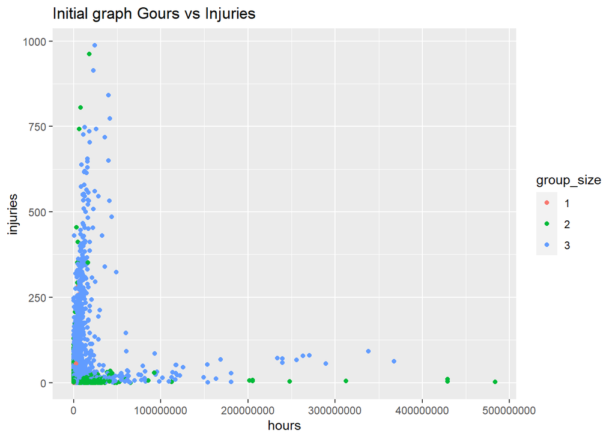

```r
osha<-read_csv("OshaData2016.csv")
train<- osha%>%
  mutate( injuries = osha$total_injuries, hours = osha$total_hours_worked,
         group_size = osha$size, employees = osha$annual_average_employees) %>%
  dplyr::select(injuries, hours, group_size, state, employees)%>%
  drop_na()%>%
  filter( injuries < 1000, hours < 500000000, hours > 1)
train$group_size<-as.factor(train$group_size)

#just plot itself!
ggplot(train, aes(x = hours, y = injuries, color = group_size))+
  geom_point()+
  labs(title = "Initial graph Gours vs Injuries")
```

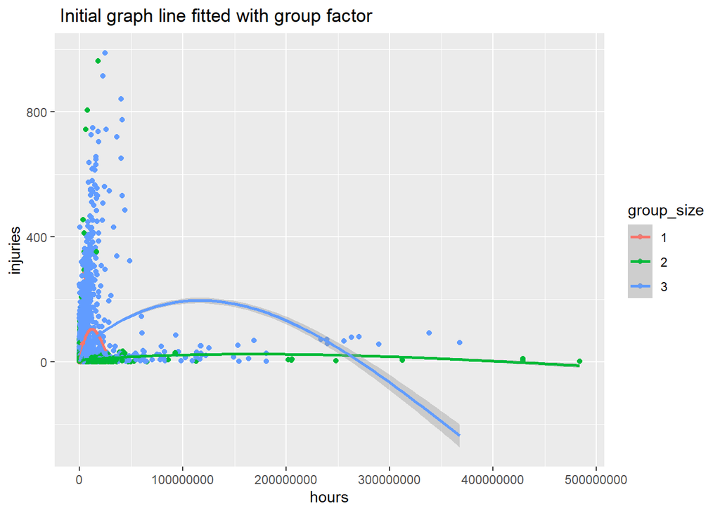

```r
#plot with geom smooth. bad
ggplot(train, aes(x = hours, y = injuries, color = group_size))+
  geom_point()+
  geom_smooth()+
  labs(title = " Initial graph line fitted with group factor" )
```

#Log transform might help?

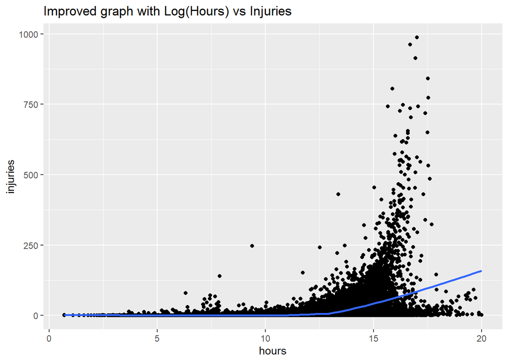

```r
#log transform with factor
trainA<-train
trainA$group_size<-as.factor(trainA$group_size)
trainA$hours<-log(trainA$hours)

ggplot(trainA, aes(x = hours, y = injuries))+
  geom_point()+
  geom_smooth()+
  labs(title = "Improved graph with Log(Hours) vs Injuries ")
```

Based on this, it seems reasonable to fit a model of the form
$$\log( \mu ) ~ = ~ a + bx \ ,$$
where $\mu$ is the mean response and $x$ is the one and only (quantitative) predictor. An important consideration, though, is whether the response seems to follow the Poisson distribution or the negative binomial distribution – i.e., are its conditional mean and variance roughly the same or not?

#Poisson or Negative Binomial Regression?

```r
MeanT<- mean(train$injuries)
VarianceT<-var(train$injuries)
(RatioT<- VarianceT/MeanT)
```

```
[1] 55.76482
```

```r
#use negative binomial model for whole data because var and mean don't match!!
```

#Graph all together no factor

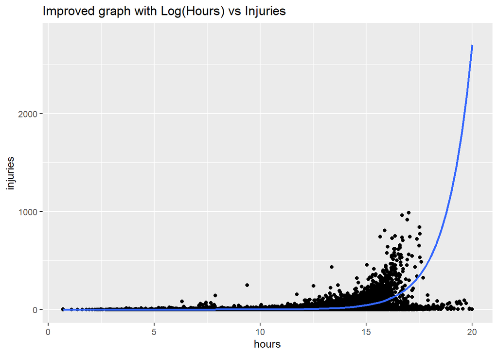

```r
ggplot(trainA, aes(x = hours, y = injuries), color = group_size)+
  geom_point()+
  geom_smooth(method = "glm.nb")+
  labs(title = "Improved graph with Log(Hours) vs Injuries ")
```

#Graph all together with factor

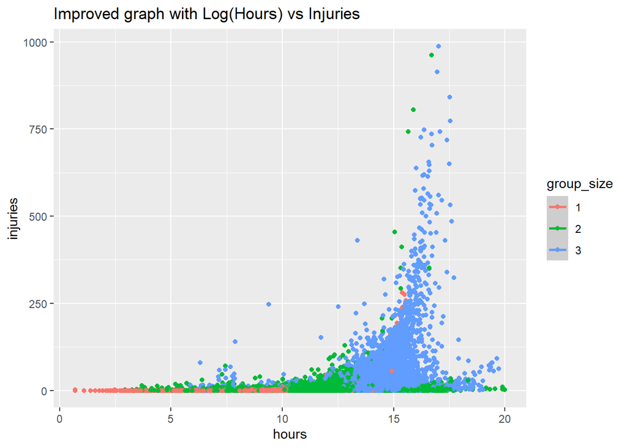

```r
ggplot(trainA, aes(x = hours, y = injuries, color = group_size))+
  geom_point()+
  geom_smooth(method = "glm.nb")+
  labs(title = "Improved graph with Log(Hours) vs Injuries ")
```

#Graph by factor and fit Begative Binomial Line to it

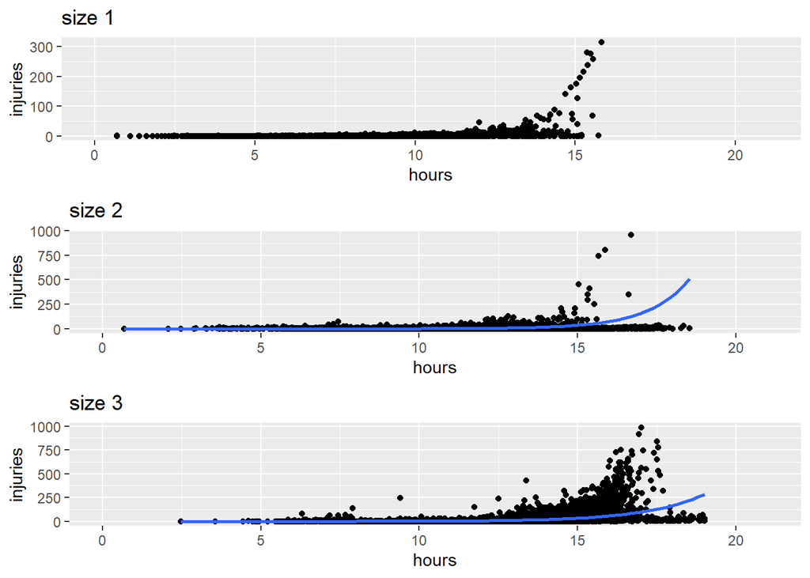

```r
#start with group size 1 (small)________________________________________________
{train1<-train%>%
  filter(group_size == 1, hours < 10000000 )

Mean1<- mean(train1$injuries)
Variance1<-var(train1$injuries)
(Ratio1<- Variance1/Mean1)

train1$hours<- log(train1$hours)

Plot1<-ggplot(train1, aes(x = hours, y = injuries)) +
  geom_point()+
  geom_smooth(method = "glm.nb")+
  labs(title = "size 1")+
  xlim(0,21)
}
#start with group size 2 (medium)_______________________________________________
{train2<-train%>%
  filter(group_size == 2 , hours<150000000)

Mean2<- mean(train2$injuries)
Variance2<-var(train2$injuries)
(Ratio2<- Variance2/Mean2)

train2$hours<- log(train2$hours)

Plot2<-ggplot(train2, aes(x = hours, y = injuries)) +
  geom_point()+
  geom_smooth(method = "glm.nb")+
  labs(title = "size 2")+
  xlim(0,21)
}
#start with group size 3 (larger)_______________________________________________
{train3<-train%>%
  filter(group_size == 3, hours < 200000000)

Mean3<- mean(train3$injuries)
Variance3<-var(train3$injuries)
(Ratio3<- Variance3/Mean3)

train3$hours<- log(train3$hours)

Plot3<-ggplot(train3, aes(x = hours, y = injuries)) +
  geom_point()+
  geom_smooth(method= "glm.nb")+
  labs(title = "size 3")+
  xlim(0,21)
}
#graph all______________________________________________________________________
grid.arrange(Plot1, Plot2, Plot3, ncol=1)
```

#Now Null Negative Binomial Model!

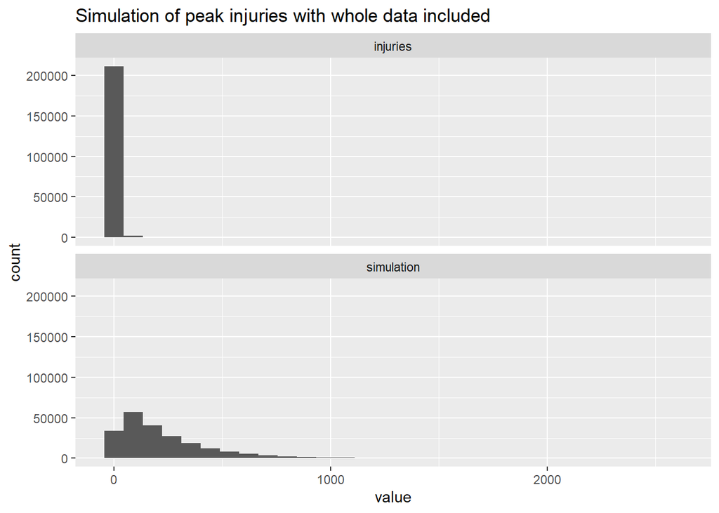

```r
#null model_____________________________________________________________________
{trainA.fit<-glm.nb(injuries~hours, data = trainA)
summary(trainA.fit)

#null model to simulate peak of group 3 peak of all data
new_data <- data.frame( hours = log(24537640))
mu <- predict( trainA.fit, newdata = new_data, type="response")
trainAS <- trainA %>%
  mutate( simulation = rnbinom( nrow(trainA), mu=mu[1], size=trainA.fit$theta))

ggplot( trainAS %>% dplyr::select( injuries, simulation) %>% pivot_longer(injuries:simulation),
        aes(value)) +
  geom_histogram() +
  facet_wrap(~name, ncol=1) +
  labs( title="Simulation of peak injuries with whole data included")
}
```

#Now Negative Binomial Model to predict peak values of each size group

```r
#model using size factor________________________________________________________
{train.fit<-glm.nb(injuries~hours+group_size, data = trainA)
summary(train.fit)
}
```

```
Call:
glm.nb(formula = injuries ~ hours + group_size, data = trainA,
    init.theta = 1.100264481, link = log)

Deviance Residuals:
    Min       1Q   Median       3Q      Max
-3.4523  -1.0321  -0.4042   0.2971  21.0109

Coefficients:
             Estimate Std. Error z value            Pr(>|z|)
(Intercept) -7.870245   0.030249 -260.18 <0.0000000000000002 ***
hours        0.710773   0.002857  248.74 <0.0000000000000002 ***
group_size2  0.587373   0.012219   48.07 <0.0000000000000002 ***
group_size3  0.955474   0.016229   58.88 <0.0000000000000002 ***
---
Signif. codes:  0 '***' 0.001 '**' 0.01 '*' 0.05 '.' 0.1 ' ' 1

(Dispersion parameter for Negative Binomial(1.1003) family taken to be 1)

    Null deviance: 474676  on 213460  degrees of freedom
Residual deviance: 221923  on 213457  degrees of freedom
AIC: 886139

Number of Fisher Scoring iterations: 1

              Theta:  1.10026
          Std. Err.:  0.00536

 2 x log-likelihood:  -886128.74900
```

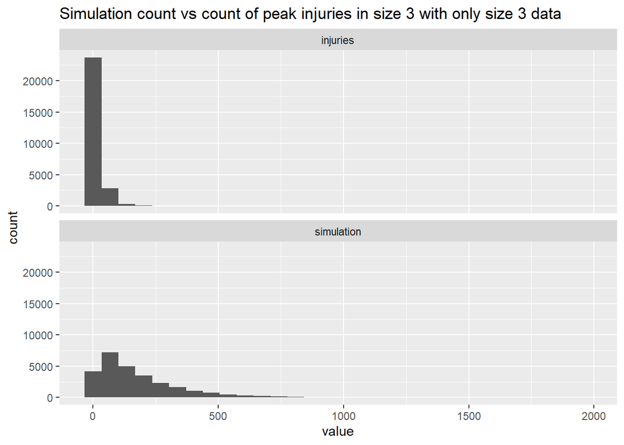

```r
#simulations peak in all group 3
{new_data <- data.frame( hours = log(24537640), group_size = "3")
mu <- predict( train.fit, newdata = new_data, type="response")
train3S <- train3 %>%
  mutate( simulation = rnbinom( nrow(train3), mu=mu[1], size=train.fit$theta))

ggplot( train3S %>% dplyr::select( injuries, simulation) %>% pivot_longer(injuries:simulation),
        aes(value)) +
  geom_histogram() +
  facet_wrap(~name, ncol=1) +
  labs( title="Simulation count vs count of peak injuries in size 3 with only size 3 data")
}
```

#Simulate by chunks

Due to the size of dataset, and the distribution it didn’t work well when simulating peak with whole dataset, what about we instead take chunks of data and try to simulate those!

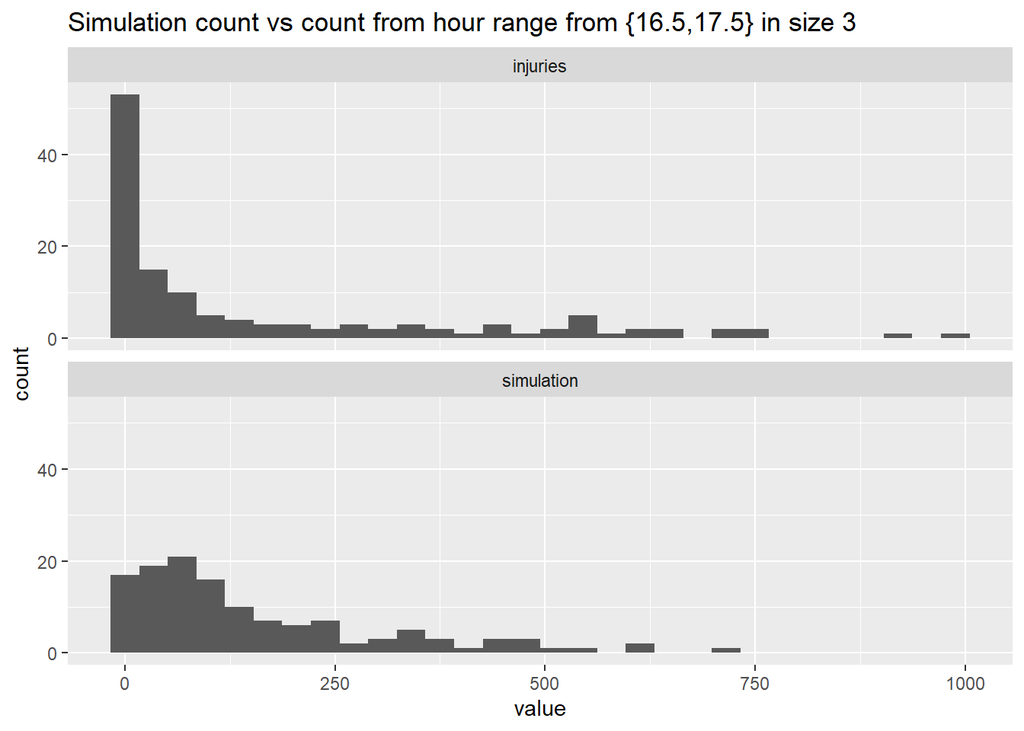

```r
#model with observations similar to hours of the peak of group 3________________
{trainP3<- train3%>%
  filter( 16.5<hours, hours < 17.5 )

#plot these observations
ggplot(trainP3, aes(injuries))+
  geom_histogram()+
  labs(title = "Count from hour range from {16.5,17.5} in size 3")

#simulations peak in 16.5 - 17.5
new_data <- data.frame( hours = log(24537640), group_size = "3")
mu <- predict( train.fit, newdata = new_data, type="response")
trainP3S <- trainP3 %>%
  mutate( simulation = rnbinom( nrow(trainP3), mu=mu[1], size=train.fit$theta))

ggplot( trainP3S %>% dplyr::select( injuries, simulation) %>% pivot_longer(injuries:simulation),
        aes(value)) +
  geom_histogram() +
  facet_wrap(~name, ncol=1) +
  labs( title="Simulation count vs count from hour range from {16.5,17.5} in size 3")
}
```

[figure not shown]

```r
#model with observations similar to hours of the peak of group 2________________
{trainP2<- train2%>%
  filter( 16.2<hours, hours < 17.2)

#plot these observations
ggplot(trainP2, aes(injuries))+
  geom_histogram()+
  labs(title = "Count from hour range from {16.2,17.2} in size 2")

#simulations peak in 16.2 - 17.2
new_data <- data.frame( hours = log(17793934), group_size = "2")
mu <- predict( train.fit, newdata = new_data, type="response")
trainP2S <- trainP2 %>%
  mutate( simulation = rnbinom( nrow(trainP2), mu=mu[1], size=train.fit$theta))

ggplot( trainP2S %>% dplyr::select( injuries, simulation) %>% pivot_longer(injuries:simulation),
        aes(value)) +
  geom_histogram() +
  facet_wrap(~name, ncol=1) +
  labs( title="Simulation count vs count from hour range from {16.3,17.3} in size 2 ")
}
```